# Assignment II

Katarzyna Piotrowska

2022-04-06

[figure not shown]

**The Office** is an American television sitcom broadcast on *NBC*. Created as an adaptation by *Greg Daniels* of the British series of the same name, it is a mockumentary that follows the day-to-day lives of the employees of the Scranton, Pennsylvania branch of *Dunder Mifflin*, a fictional paper supply company. The series ran on *NBC* in the United States from March 24, 2005, to May 16, 2013. Additionally, nine spin-off series of webisodes of *The Office* have been aired on *NBC.com*.

[figure not shown]

**Basic statistics about the series.**

| Season | Number.of.Episodes | Rank | Average.viewership |
| --- | --- | --- | --- |
| 1 | 6 | 102 | 5.4 |
| 2 | 22 | 67 | 8.0 |
| 3 | 25 | 68 | 8.3 |
| 4 | 19 | 77 | 8.9 |
| 5 | 28 | 52 | 9.0 |
| 6 | 26 | 52 | 7.8 |
| 7 | 26 | 53 | 7.7 |
| 8 | 24 | 87 | 6.5 |
| 9 | 25 | 94 | 5.1 |

**Average viewership for each season.**

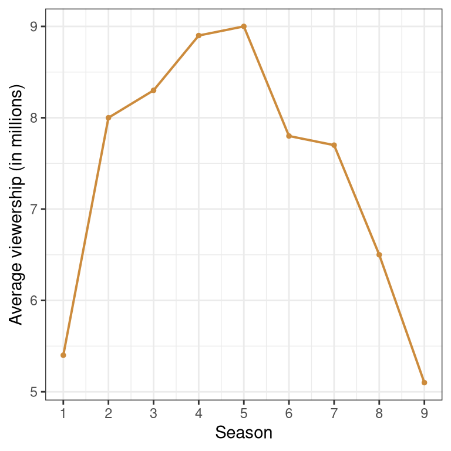

**The position of each season in the rankings.**

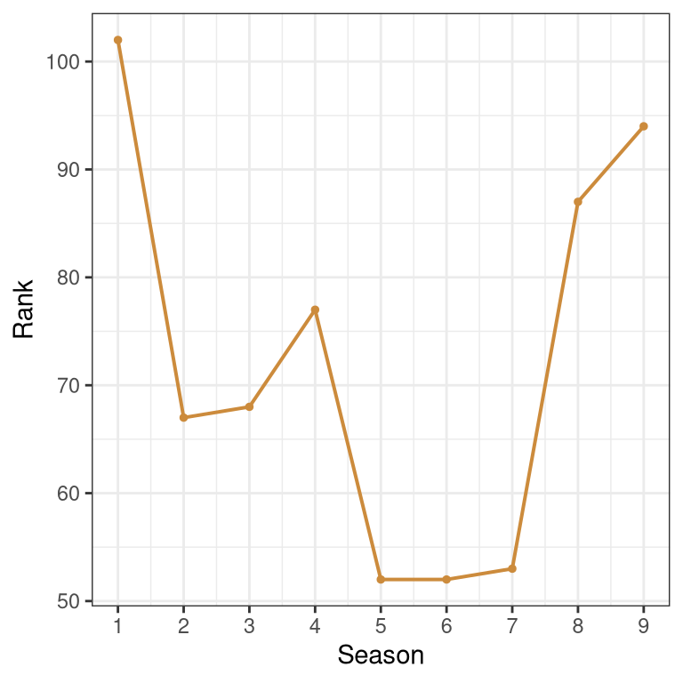

**The episode-to-episode changes in viewership.**

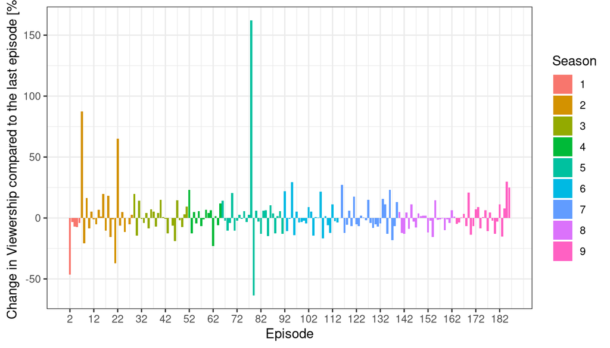

#### Observations

The average viewership of **The Office** decreased by -5.56 percent between seasons 1 and 9.  
The viewership of the last season was 5.1 million.  
On the other hand, the most popular was season number 5 for which the average viewership was equal 9 million.  
The highest rated seasons were season number 5 and 6, which ranked #52.  
By comparison, season number 1 was the worst, which ranked #102.

#### Source

The entire task was prepared based on the website:  
https://en.wikipedia.org/wiki/List_of_The_Office_(American_TV_series)_episodes